# Report

Filippo Gambarota

2022-03-22

```r
library(tidyverse)
library(here)
library(kableExtra)
library(ggeffects)
```

```r
qtheme <- function(){
    theme_minimal(base_size = 12)
}

qtab <- function(data){
  data %>%
    kable(digits = 3) %>%
    kable_styling(bootstrap_options = c("striped", "condensed"),
                  full_width = FALSE)
}

get_threshold <- function(fit){
  -(coef(fit)[1]/coef(fit)[2])
}

get_slope <- function(fit){
  1/coef(fit)[2]
}
```

```r
file <- "local-files/1_(2022-03-18_09-31-23).csv"
dat <- read_csv(here(file))
```

```r
if (dat$subject[1] == "1") {
  # reverse scores
  dat$test <- ifelse(dat$test == "same", "change", "same")
}

dat <- dat %>%
  mutate(acc = ifelse(type == test, 1, 0),
         pasf = factor(pas),
         questf = factor(quest),
         is_signal = factor(ifelse(trial_type == "valid", 1, 0)),
         say_signal = factor(ifelse(pas < 2, 0, 1)))
```

# 1 Report

## 1.1 QUEST overview

This plot represent the overall QUESTs across the experiment for valid trials only. The red dot are the contrast 0 (this is an index on how low is the contrast across trials).

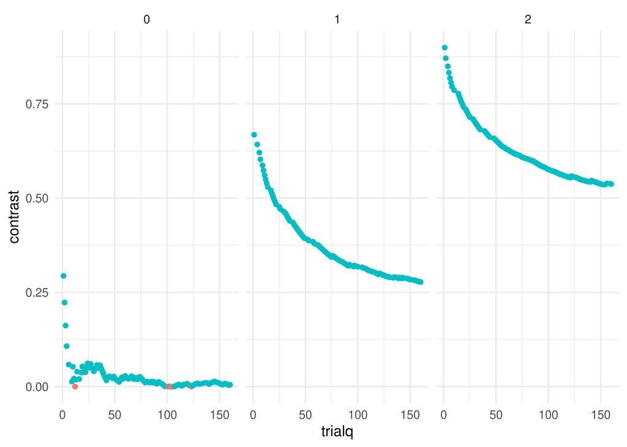

```r
dat %>%
  group_by(quest) %>%
  mutate(trialq = 1:n(),
         contr = ifelse(contrast == 0, 0, 1)) %>%
  ungroup() %>%
  filter(trial_type == "valid") %>%
  ggplot(aes(x = trialq, y = contrast, color = factor(contr))) +
  geom_point(show.legend = FALSE) +
  facet_wrap(~quest) +
  qtheme()
```

This table is the average contrast with variability for each QUEST:

```r
dat %>%
  filter(trial_type == "valid") %>%
  group_by(quest) %>%
  summarise(mean = mean(contrast),
         sd = sd(contrast),
         min = min(contrast),
         first_quantile = quantile(contrast, 0.25),
         median = median(contrast),
         third_quantile = quantile(contrast, 0.75),
         max = max(contrast)) %>%
  qtab()
```

| quest | mean | sd | min | first_quantile | median | third_quantile | max |
| --- | --- | --- | --- | --- | --- | --- | --- |
| 0 | 0.025 | 0.038 | 0.000 | 0.007 | 0.013 | 0.026 | 0.294 |
| 1 | 0.370 | 0.091 | 0.277 | 0.300 | 0.338 | 0.412 | 0.668 |
| 2 | 0.624 | 0.084 | 0.536 | 0.556 | 0.598 | 0.669 | 0.899 |

This is the PAS distribution for QUEST and trial type (catch and valid):

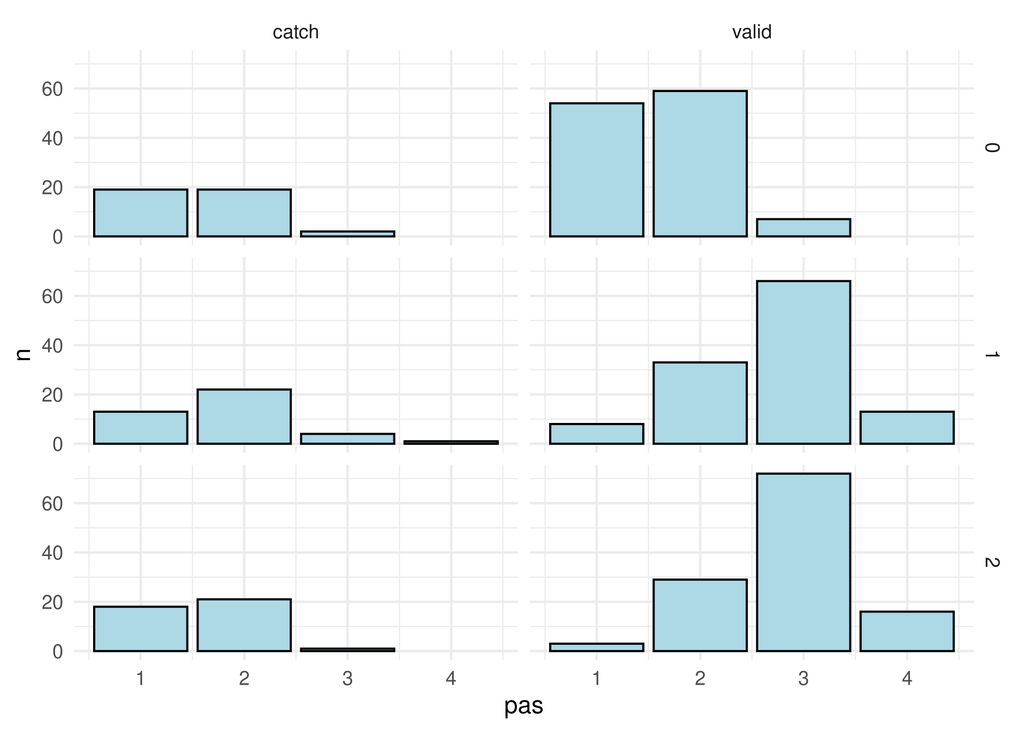

```r
dat %>%
  count(pas, trial_type, quest) %>%
  ggplot(aes(x = pas, y = n)) +
  geom_col(color = "black", fill = "lightblue") +
  facet_grid(quest~trial_type) +
  qtheme()
```

This is the table for PAS and QUEST contrast with variability:

```r
dat %>%
  group_by(quest, pas) %>%
  summarise(mean = mean(contrast),
            sd = sd(contrast),
            ntrials = n(),
            min = min(contrast),
            first_quantile = quantile(contrast, 0.25),
            median = median(contrast),
            third_quantile = quantile(contrast, 0.75),
            max = max(contrast)) %>%
  qtab()
```

| quest | pas | mean | sd | ntrials | min | first_quantile | median | third_quantile | max |
| --- | --- | --- | --- | --- | --- | --- | --- | --- | --- |
| 0 | 1 | 0.011 | 0.014 | 73 | 0.000 | 0.000 | 0.007 | 0.020 | 0.050 |
| 0 | 2 | 0.023 | 0.043 | 78 | 0.000 | 0.000 | 0.011 | 0.026 | 0.294 |
| 0 | 3 | 0.039 | 0.059 | 9 | 0.000 | 0.003 | 0.007 | 0.057 | 0.162 |
| 1 | 1 | 0.115 | 0.151 | 21 | 0.000 | 0.000 | 0.000 | 0.287 | 0.344 |
| 1 | 2 | 0.215 | 0.196 | 55 | 0.000 | 0.000 | 0.285 | 0.327 | 0.668 |
| 1 | 3 | 0.354 | 0.115 | 70 | 0.000 | 0.308 | 0.351 | 0.418 | 0.621 |
| 1 | 4 | 0.376 | 0.152 | 14 | 0.000 | 0.288 | 0.395 | 0.504 | 0.561 |
| 2 | 1 | 0.078 | 0.195 | 21 | 0.000 | 0.000 | 0.000 | 0.000 | 0.554 |
| 2 | 2 | 0.359 | 0.318 | 50 | 0.000 | 0.000 | 0.546 | 0.580 | 0.899 |
| 2 | 3 | 0.618 | 0.105 | 73 | 0.000 | 0.565 | 0.610 | 0.662 | 0.849 |
| 2 | 4 | 0.638 | 0.091 | 16 | 0.536 | 0.548 | 0.612 | 0.708 | 0.777 |

This table is the accuracy as a function of PAS and QUEST

```r
dat %>%
  group_by(quest, pas) %>%
  summarise(acc = mean(acc),
            ntrials = n(),
            contrast = mean(contrast)) %>%
  qtab()
```

| quest | pas | acc | ntrials | contrast |
| --- | --- | --- | --- | --- |
| 0 | 1 | 0.370 | 73 | 0.011 |
| 0 | 2 | 0.538 | 78 | 0.023 |
| 0 | 3 | 0.778 | 9 | 0.039 |
| 1 | 1 | 0.714 | 21 | 0.115 |
| 1 | 2 | 0.727 | 55 | 0.215 |
| 1 | 3 | 0.914 | 70 | 0.354 |
| 1 | 4 | 1.000 | 14 | 0.376 |
| 2 | 1 | 0.476 | 21 | 0.078 |
| 2 | 2 | 0.700 | 50 | 0.359 |
| 2 | 3 | 0.932 | 73 | 0.618 |
| 2 | 4 | 1.000 | 16 | 0.638 |

This is the relationship between accuracy and contrast:

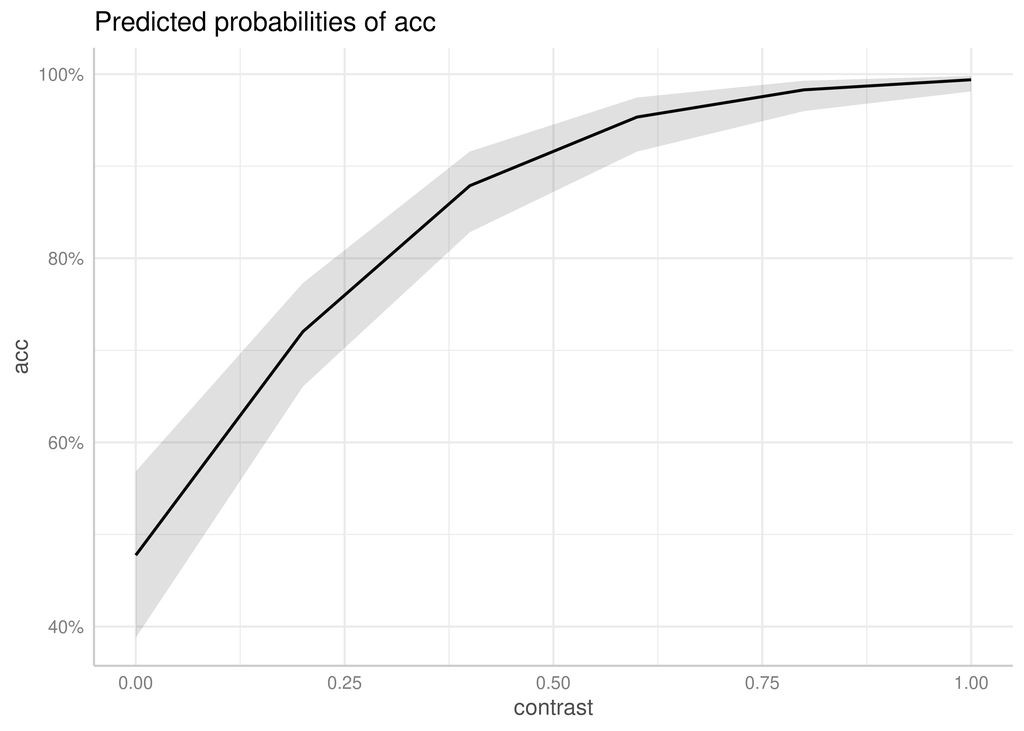

```r
fit_con <- glm(acc ~ contrast,
               data = dat %>% filter(trial_type == "valid"),
               family = binomial(link = "logit"))

plot(ggeffect(fit_con))
```

This is the signal detection analysis. Negative criterion value represent a tendency toward responding “yes” (liberal criterion)

```r
dat %>%
  mutate(sdt = case_when(is_signal == 1 & say_signal == 1 ~ "hit",
                         is_signal == 1 & say_signal == 0 ~ "miss",
                         is_signal == 0 & say_signal == 1 ~ "fa",
                         is_signal == 0 & say_signal == 0 ~ "cr")) %>%
  count(sdt, quest) %>%
  pivot_wider(names_from = sdt, values_from = n) %>%
  mutate(fa_rate = fa/(fa + cr),
         hit_rate = hit/(hit + miss),
         dprime = qnorm(hit_rate) - qnorm(fa_rate),
         crit = -((qnorm(hit_rate) + qnorm(fa_rate))/2)) %>%
  qtab()
```

| quest | cr | fa | hit | miss | fa_rate | hit_rate | dprime | crit |
| --- | --- | --- | --- | --- | --- | --- | --- | --- |
| 0 | 19 | 21 | 66 | 54 | 0.525 | 0.550 | 0.063 | -0.094 |
| 1 | 13 | 27 | 112 | 8 | 0.675 | 0.933 | 1.047 | -0.977 |
| 2 | 18 | 22 | 117 | 3 | 0.550 | 0.975 | 1.834 | -1.043 |

This is the psychometric function considering PAS 1 as 0 and PAS 234 as 1.

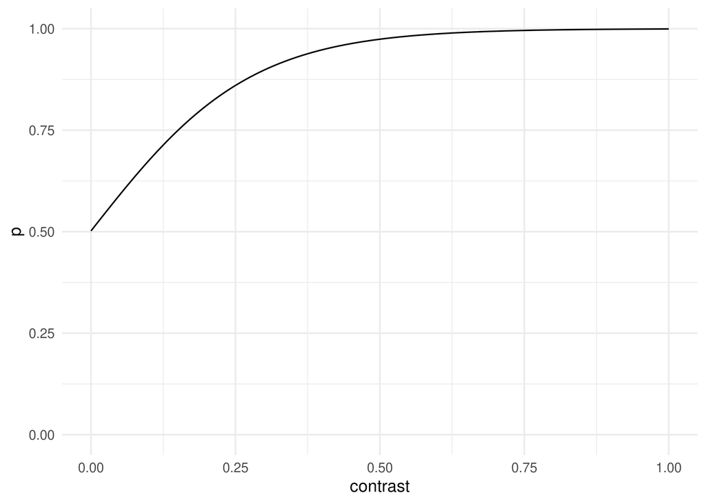

```r
fit_pas1_234 <- glm(vis ~ contrast,
           data = dat %>% filter(trial_type == "valid"),
           family = binomial(link = "logit"))

newdata <- data.frame(contrast = seq(0,1,0.001))

newdata$p <- predict(fit_pas1_234, newdata = newdata, type = "response")

ggplot(newdata) +
  geom_line(aes(x = contrast, y = p)) +
  ylim(c(0,1)) +
  qtheme()
```

The estimated 50% threshold is -0.001 and the slope is 0.138

This is the psychometric function considering PAS 12 as 0 and PAS 34 as 1. I’m not sure if this is meaningful but is a more plausible psychometric function

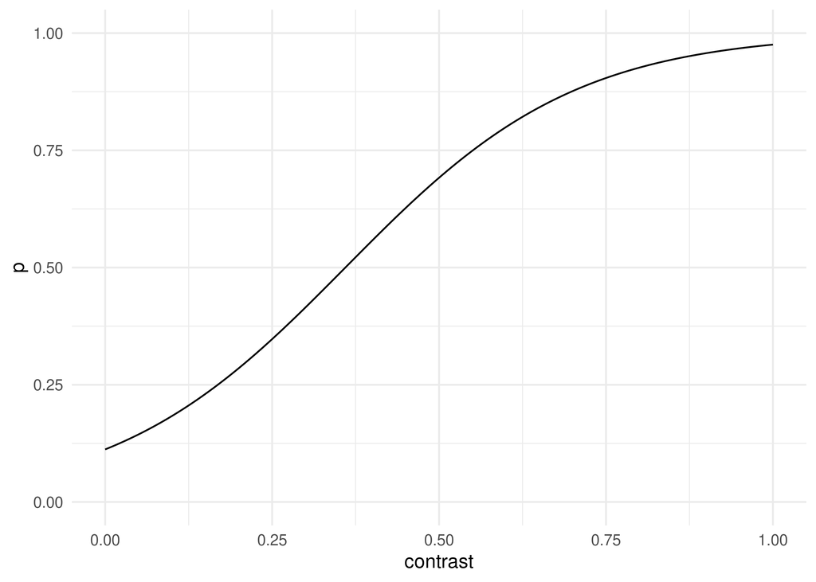

```r
dat$vis12 <- ifelse(dat$pas <= 2, 0, 1)

fit_pas12_34 <- glm(vis12 ~ contrast,
           data = dat %>% filter(trial_type == "valid"),
           family = binomial(link = "logit"))

newdata <- data.frame(contrast = seq(0,1,0.001))

newdata$p <- predict(fit_pas12_34, newdata = newdata, type = "response")

ggplot(newdata) +
  geom_line(aes(x = contrast, y = p)) +
  ylim(c(0,1)) +
  qtheme()
```